# Assignment 2 - Introduction to Computational Finance and Financial Econometrics

T Xu

September 25, 2014

## Question 1

Hint: you can use the R functions pnorm and qnorm to answer these questions. (5) Suppose X is a normally distributed random variable with mean 0.05 and variance (0.10)2. Compute the following. a) $Pr(X>.10)$

```r
pnorm(0.1,mean=0.05,sd=0.1,lower.tail=F)
```

```
## [1] 0.3085
```

## Question 2

Suppose X is a normally distributed random variable with mean 0.05 and variance (0.10)2. Compute the following. b) $Pr(X < -.10)$

```r
pnorm(-0.1,mean=0.05,sd=0.1,lower.tail=T)
```

```
## [1] 0.06681
```

## Question 3

Suppose X is a normally distributed random variable with mean 0.05 and variance (0.10)2. Compute the following. c) $Pr(-0.05<X<0.15)$

```r
pnorm(0.15,mean=0.05,sd=0.1)-pnorm(-0.05,mean=0.05,sd=0.1)
```

```
## [1] 0.6827
```

## Question 4

Suppose X is a normally distributed random variable with mean 0.05 and variance (0.10)2. Compute the following.

4. 1% quantile, q.01

```r
qnorm(0.01,mean=0.05,sd=0.1)
```

```
## [1] -0.1826
```

## Question 5

Suppose X is a normally distributed random variable with mean 0.05 and variance (0.10)2. Compute the following. e) 5% quantile, q.05

```r
qnorm(0.05,mean=0.05,sd=0.1)
```

```
## [1] -0.1145
```

## Question 6

Suppose X is a normally distributed random variable with mean 0.05 and variance (0.10)2. Compute the following. f) 95% quantile, q.95

```r
qnorm(0.95,mean=0.05,sd=0.1)
```

```
## [1] 0.2145
```

## Question 7

Suppose X is a normally distributed random variable with mean 0.05 and variance (0.10)2. Compute the following. g) 99% quantile, q.99

```r
qnorm(0.99,mean=0.05,sd=0.1)
```

```
## [1] 0.2826
```

## Question 8

Let X denote the monthly return on Microsoft Stock and let Y denote the monthly return on Starbucks stock. Assume that X~N(0.05,(0.10)2) and Y~N(0.025,(0.05)2). Using a grid of values between 0.25 and 0.35, plot the normal curves for X and Y. Make sure that both normal curves are on the same plot. (5) Which stock has the higher risk?

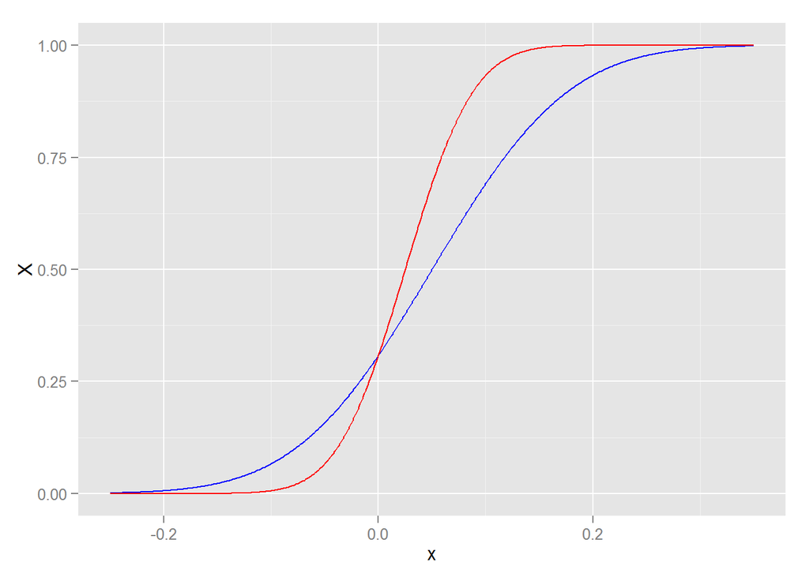

```r
#install.packages('ggplot2', dep = TRUE)
#install.packages("munsell")
library(ggplot2)
x <-seq(-0.25,0.35,by=0.001)
X <- pnorm(x, mean=0.05, sd=0.1) #Microsoft
Y <- pnorm(x, mean=0.025, sd=0.05) # Starbucks
df <- data.frame(x,X,Y)
# blue <- Microsoft; red <- Starbucks
ggplot(df, aes(x)) + geom_line(aes(y=X),color="blue")+geom_line(aes(y=Y),color="red")
```

## Question 9

Let R denote the simple monthly return on Microsoft stock and let W0 denote the initial wealth to be invested over the month. Assume that R~N(0.04,(0.09)2)) and that W0=$100,000 (10) Determine the 1% and 5% value-at-risk (VaR) over the month on the investment. That is, determine the loss in investment value that may occur over the next month with 1% probability and with 5% probability.

```r
W0 <- 100000
VaRR001 <- qnorm(0.01,mean=0.04,sd=0.09) * W0
VaRR005 <- qnorm(0.05,mean=0.04,sd=0.09) * W0
VaRR001
```

```
## [1] -16937
```

```r
VaRR005
```

```
## [1] -10804
```

## Question 10

Let the r denote the continuously compounded monthly return on Microsoft stock and let W0 denote the initial wealth to be invested over the month. Assume that r~iid N(0.04,(0.09)2) and that W0=$100,000. (10) Determine the 1% and 5% value-at-risk (VaR) over the month on the investment. That is, determine the loss in investment value that may occur over the next month with 1% probability and with 5% probability. (Hint: compute the 1% and 5% quantile from the Normal distribution for r and then convert continuously compounded return quantile to a simple return quantile using the transformation R=er-1)

```r
W0 <- 100000
VaRr <- function(q){
  r <- qnorm(q,mean=0.04,sd=0.09)
  exp(r)-1
}
VaRr001 <- VaRr(0.01) * W0
VaRr005 <- VaRr(0.05) * W0
VaRr001
```

```
## [1] -15580
```

```r
VaRr005
```

```
## [1] -10241
```

## Question 11

For the following questions:

Consider a one month investment in two Northwest stocks: Amazon and Costco. Suppose you buy Amazon and Costco at the end of September at PA,t-1=$38.23, PC,t-1=$41.11 and then sell at the end of October for PA,t=$41.29, PC,t=$41.74. (Note: these are actual closing prices for 2004 taken from Yahoo!) (10) What are the simple monthly returns for the two stocks?

```r
PA0 <- 38.23; PA1 <- 41.29
PC0 <- 41.11; PC1 <- 41.74
paste("Q11Amazon", PA1/PA0-1)
```

```
## [1] "Q11Amazon 0.0800418519487314"
```

```r
paste("Q11Costco", PC1/PC0-1)
```

```
## [1] "Q11Costco 0.0153247385064461"
```

## Question 12

10. What are the continuously compounded returns for the two stocks?

```r
paste("Q12Amazon", log(PA1)-log(PA0))
```

```
## [1] "Q12Amazon 0.0769997921896777"
```

```r
paste("Q12Costco", log(PC1)-log(PC0))
```

```
## [1] "Q12Costco 0.0152085007392677"
```

## Question 13

10. Suppose Amazon paid a $0.10 per share cash dividend at the end of October. What is the monthly simple total return on Amazon? What is the monthly dividend yield?

```r
ADiv <- 0.1
paste("Q13 Total Return", (PA1+ADiv)/PA0-1)
```

```
## [1] "Q13 Total Return 0.0826575987444416"
```

```r
paste("Q12 Div Yield", ADiv/PA0)
```

```
## [1] "Q12 Div Yield 0.00261574679571018"
```

## Question 14

10. Suppose the monthly returns on Amazon from question 12 above are the same every month for 1 year. Compute the simple annual returns, as well as the continuously compounded annual returns.

```r
Q12Ret <- log(PA1)-log(PA0)
paste("Q14 Simple Annual", exp(Q12Ret*12)-1)
```

```
## [1] "Q14 Simple Annual 1.51934137006217"
```

```r
paste("Q14 Total Return", Q12Ret*12)
```

```
## [1] "Q14 Total Return 0.923997506276132"
```

## Question 15

10. At the end of September 2004, supposed you have $10,000 to invest in Amazon and Costco over the next month. If you invest $8,000 in Amazon and $2,000 in Costco, what are your portfolio shares, xA and xC.

```r
xA <- 8000
xC <- 2000
```

## Question 16

10. Continuing with the previous question, compute the monthly simple return on the portfolio. Assume than no dividends are paid.

```r
P0 <- xA + xC
P1 <- xA*PA1/PA0 + xC*PC1/PC0
P1/P0-1
```

```
## [1] 0.0671
```